# PUBHBIO 6211: Practice Exercises Block 11

# Exercise 1

A Wilcoxon rank sum test was performed to compare the two groups; Stata output is below.

```stata
. ranksum hemo, by(group)

Two-sample Wilcoxon rank-sum (Mann-Whitney) test

       group |      obs    rank sum    expected
-------------+---------------------------------
           0 |       10       137.5         105
           1 |       10        72.5         105
-------------+---------------------------------
    combined |       20         210         210

unadjusted variance      175.00
adjustment for ties       -1.05
                     ----------
adjusted variance        173.95

Ho: hemo(group==0) = hemo(group==1)
             z =   2.464
    Prob > |z| =   0.0137
```

1. What are the null and alternative hypotheses for this test?
2. What is the value of the test statistic, its distribution under the null, and the p-value for this test?
3. Write a one-sentence conclusion (in context) based on the results of this test. Assume $\alpha=0.05$.
4. The largest value of hemoglobin in the data set is 18. Suppose this were a typo, and this one value was really 32. How would the result of the Wilcoxon rank sum test change? (In other words, if we replace the largest value of 18 with the value 32, what happens to the test result?)

# Exercise 2

We have permeability constants of the human chorioamnion (a placental membrane) taken at two time points: 40 weeks gestational age (GA), and between 12 to 26 weeks GA. Note that these measurements were all on different pregnant women (not the same women measured twice). A nonparametric test was used to determine if there is different permeability of the human chorioamnion by GA. Write a one sentence conclusion of the results of this test, including reference to a p-value. Assume $\alpha=0.05$.

```stata
. ranksum perm, by(ga)

Two-sample Wilcoxon rank-sum (Mann-Whitney) test

          ga |      obs    rank sum    expected
-------------+---------------------------------
    40 weeks |       10          90          80
 12-26 weeks |        5          30          40
-------------+---------------------------------
    combined |       15         120         120

unadjusted variance       66.67
adjustment for ties        0.00
                     ----------
adjusted variance         66.67

Ho: perm(ga==40 weeks) = perm(ga==12-26 weeks)
             z =   1.225
    Prob > |z| =   0.2207
```

# Exercise 3

A survey of a random sample of students at the University of New Hampshire was conducted. School administrators would like to use these data to test whether there are differences between male and female students in the number of hours they report studying per week (`study`).

1. A histogram of the hours studied, separated by gender, was produced and is below. Explain why we might want to use a nonparametric test to compare the two groups instead of a parametric one, and state which nonparametric test would be appropriate to use.

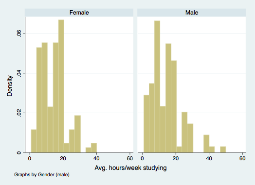

Side-by-side Histograms

2. The nonparametric test was run in Stata, output is below. Draw a conclusion from the test (in context), referencing a p-value. Assume $\alpha=0.05$.

```stata
Two-sample Wilcoxon rank-sum (Mann-Whitney) test

      gender |      obs    rank sum    expected
-------------+---------------------------------
      Female |      133     16232.5       15960
        Male |      106     12447.5       12720
-------------+---------------------------------
    combined |      239       28680       28680

unadjusted variance   281960.00
adjustment for ties    -3783.87
                     ----------
adjusted variance     278176.13

Ho: study(gender==Female) = study(gender==Male)
             z =   0.517
    Prob > |z| =   0.6054
```

3. If we are willing to assume that the shape of the distributions is the same in both groups, what is another way we could state our conclusion?

# Exercise 4

A survey of a random sample of students at the University of New Hampshire was conducted. School administrators would like to use these data to test whether there are differences among students based on year in school (`year`) in the number of hours they report studying per week (`study`). A nonparametric test was used to test this; Stata output is below. Write a one sentence conclusion of the results of this test, including reference to a p-value. Assume $\alpha=0.05$.

```stata
. kwallis study, by(year)

Kruskal-Wallis equality-of-populations rank test

  +----------------------------+
  |      year | Obs | Rank Sum |
  |-----------+-----+----------|
  |  Freshman |  39 |  5150.00 |
  | Sophomore |  64 |  7011.50 |
  |    Junior |  73 |  9137.00 |
  |    Senior |  63 |  7381.50 |
  +----------------------------+

chi-squared =     3.159 with 3 d.f.
probability =     0.3678

chi-squared with ties =     3.202 with 3 d.f.
probability =     0.3615
```

# Exercise 5

A survey of a random sample of students at the University of New Hampshire was conducted. Information was collected on the amount of alcohol students consumed. The result was a 33-point drinking scale score, where a higher score means more alcohol consumption. We are interested in whether there are differences in alcohol consumption among the years in school (`year`: 1=Freshman, 2=Sophomore, 3=Junior, 4=Senior). However, we are concerned that the distribution of the drinking scores might not be normal within each group, so we use a Kruskal-Wallis test. Stata output is below.

```stata
. kwallis drink, by(year)

Kruskal-Wallis equality-of-populations rank test

  +----------------------------+
  |      year | Obs | Rank Sum |
  |-----------+-----+----------|
  |  Freshman |  40 |  4914.00 |
  | Sophomore |  65 |  9341.50 |
  |    Junior |  75 |  9300.50 |
  |    Senior |  63 |  6090.00 |
  +----------------------------+

chi-squared =    14.453 with 3 d.f.
probability =     0.0023

chi-squared with ties =    14.490 with 3 d.f.
probability =     0.0023
```

1. What are the null and alternative hypotheses for this test?
2. What is the value of the test statistic, its distribution under the null, and the p-value for this test?
3. Write a one-sentence conclusion (in context) based on the results of this test. Assume $\alpha=0.05$.
4. The median drinking scores for each group are: freshman=19.0, sophomores=21.2, juniors=19.5, seniors=16.7. Based on this and the test result, can we conclude that seniors have significantly lower drinking scores than the other three groups? Why or why not?
5. Suppose that drinking scores really **are** normally distributed (in the population) for each group of students. Name two disadvantages of using the nonparametric Kruskal-Wallis test instead of a parametric test like ANOVA.